Reporte técnico · equipo de datos e ingeniería

# Detección automática de defectos en toallas Pipeline v2: resultados y propuesta de mejora

Documento 04 · Proyecto textile-image-defect-detector · rama `v2-recortes-ensamble` · noviembre 2026

El pipeline v2 sube el recall de toallas defectuosas de **22 % a 92 %** en un conjunto de prueba que ningún modelo vio. Lo logra con tres cambios: procesar la foto a resolución nativa por recortes, usar redes preentrenadas y calibrar el umbral por cámara. Además, el sistema queda listo para operar en la línea: un servicio vigila la carpeta de la cámara y publica un tablero en vivo. Este reporte describe el método y los resultados, explica dónde falla y propone los siguientes pasos.

92 %

recall de toallas NO OK (test, 68/74)  
v1: 22 %

28 %

falsas alarmas: toallas OK enviadas a revisión (44/157); 15 % con `recall_95`

0.8 s

tiempo de análisis por toalla  
(RTX 3060 Laptop, 6 GB)

## 1. Diagnóstico de la versión 1

- **Pérdida de resolución.** Las fotos de 5120×5120 se reducían a 640 px para YOLO y a 256 px para las CNN, es decir, 8 y 20 veces menos resolución. Un hilo de 40 px quedaba en 2 a 5 px, por debajo de lo que una red puede ver. En escala de producción, el lado menor mediano de una caja de *Hilo* es de ~35 px y el de *Costura*, de ~50 px.
- **Pocos datos y mucha fragmentación:** ~270 fotos repartidas en 14 clases, varias con menos de 10 ejemplos.
- **Validación contaminada:** en los notebooks 01–02, el set de prueba se usaba también como validación. El notebook 03 no convergió.
- **Datos nuevos sin usar:** no se aprovechaban `02_New_Annotated` (junio 2025) ni las ~800 fotos OK de abril.

## 2. Datos

| Fuente | Contenido | Toallas | Cámara | Anotación |
| --- | --- | --- | --- | --- |
| A | `01_annotated_data` (NO OK) | 226 | abril 2025, 5120×5120 | cajas, 14 clases; 48 "No visible" |
| B | `02_New_Annotated/imagenes no ok` | 262 | junio 2025, 3580×2150 | cajas, 19 clases |
| C | `02_New_Annotated/imagenes ok` | 249 | junio 2025 | solo *Etiqueta* (control) |
| D | `new_by_category/PIEZAS OK` | 801 | abril 2025 | sin cajas |
| Total |  | 1,538 | split por toalla 70/15/15: 1,076 / 231 / 231 |  |

- **Escala física común:** las fotos de abril se reducen ×0.62 para que un milímetro de tela ocupe los mismos píxeles que en la cámara de junio, que es la de producción.
- **Taxonomía unificada:** las 19 clases originales se agrupan en 6 grupos de defecto (*Mancha, Hilo, Costura, Tejido, Teñido, Empalme*) y *Etiqueta*. La etiqueta no es un defecto: es un **control** que no entra en la decisión OK/NO OK.
- **Split único por toalla**, estratificado por fuente y etiqueta y compartido por los tres modelos. Ningún recorte de una toalla de val/test se usa para entrenar.
- **Un archivo dañado:** `PIEZAS OK/20250402_114712702_0000000143_T0000_01_CAM.png` tiene un error de CRC en disco y se excluye automáticamente.

## 3. Método

### 3.1 Recortes a resolución nativa

La foto de la toalla se divide en recortes con 25 % de traslape: 1024 px para YOLO y 512 px para el clasificador y PatchCore. Una máscara por saturación HSV, con 96 px de margen, descarta los recortes que caen solo en el fondo o en la máquina. Las detecciones se unen con NMS por clase y el score de la toalla es el **máximo** sobre sus recortes. Esto es compatible con producción: entra **una foto por toalla** y sale una decisión por toalla.

### 3.2 Modelos

| Modelo | Entrenamiento | Score de toalla | AUC test |
| --- | --- | --- | --- |
| YOLO11s (ultralytics) | 3,344 recortes de 1024 px, 80 épocas, ~3.5 h | máx. confianza de un defecto | 0.815 |
| 2 × EfficientNet-B0 (timm, ImageNet) | 13k recortes de 512 px con muestreo balanceado y negativos difíciles. Modelo A: 15 épocas + 6 de ajuste; modelo B: 15 épocas, otra semilla | prom. de los 2 recortes más sospechosos (probabilidad promediada entre modelos) | 0.936 |
| PatchCore (Anomalib 2.7, WRN-50) | 1,500 recortes de toallas OK; coreset del 1 % (15,360 vectores) | máx. anomalía dentro de la máscara | 0.756 |

### 3.3 La red neuronal del clasificador

El clasificador que toma la decisión es una **red neuronal convolucional EfficientNet-B0** (≈ 4.0 millones de parámetros), preentrenada con ImageNet y ajustada con nuestros recortes. Se usan **dos copias** con la misma arquitectura y distinto entrenamiento, y se promedian sus probabilidades. El diagrama 1 muestra el camino completo de la foto a la decisión.

[figure not shown]

Diagrama 1. Recorrido de una foto. La red (azul) solo ve recortes de 512 × 512 px. La toalla se decide con los recortes más sospechosos y una calibración por cámara (naranja).

**Cómo "mira" un recorte.** Cada capa convolucional aplica muchos filtros pequeños (3 × 3 o 5 × 5 píxeles) que se deslizan por la imagen. Cada filtro es un **detector aprendido**, y su salida en cada posición equivale a una "neurona". Las primeras capas detectan bordes y texturas del rizo; las siguientes combinan esas señales en hilos, costuras o manchas. A cada etapa la imagen se hace más pequeña (512 → 16 px) y el número de detectores crece (3 → 1 280 canales): la red cambia detalle espacial por significado. Al final, un **promedio global** resume cada canal en un número (1 280 neuronas) y **una neurona de salida** con función sigmoide da la probabilidad de que el recorte tenga un defecto.

[figure not shown]

Diagrama 2. EfficientNet-B0 sobre un recorte de 512 × 512. Bajo cada bloque: tamaño de la salida (alto × ancho × canales). "MBConv6 5×5 ×2" = 2 bloques MBConv con expansión 6 y filtros de 5 × 5.

**El bloque MBConv** es la pieza que se repite 16 veces. Primero expande los canales (más detectores), luego filtra cada canal por separado (barato en cálculo) y una pequeña capa de **atención** decide qué canales importan para ese recorte. Después vuelve a comprimir los canales y suma la entrada original (**conexión residual**). Esta combinación logra mucha precisión con pocos parámetros, por eso la red corre en ≈ 1 s por toalla en una tarjeta gráfica de laptop.

[figure not shown]

Diagrama 3. Estructura de un bloque MBConv.

El mapa de calor del tablero sale de esta misma red: es la probabilidad de cada recorte, colocada en su posición dentro de la toalla.

### 3.4 Minería de negativos difíciles

Como basta un recorte para marcar la toalla, un solo recorte limpio sobre-confiado produce una falsa alarma. Tras el primer entrenamiento se calificaron *todos* los recortes de las 735 toallas OK de entrenamiento. Superaron 0.2 en 598 toallas, y se agregaron 2,601 recortes como "limpio" con peso ×3. Después se reentrenó 6 épocas con lr 1e-4. Resultado en test: el AUC por toalla subió de 0.888 a 0.935 sin calibrar.

### 3.5 Calibración por cámara y elección del umbral

Tras la minería apareció un efecto de dominio: con un umbral global, las toallas OK de abril bajaron a 10 % de falsas alarmas, pero las de junio subieron a 100 %. La razón es que el score base depende de la cámara (luz, fondo, sensor). Por eso cada score se estandariza contra las toallas OK de validación **de la misma cámara**, con un z-score robusto (mediana/IQR), y en producción se usa la calibración de junio.

El umbral se fija en validación para alcanzar un recall objetivo (90/95/98 %). El método se elige por la menor tasa de falsas alarmas en validación. Se comparan modelos individuales, la regla OR (máximo de z-scores) y stacking logístico con umbral out-of-fold. Ganó el clasificador solo.

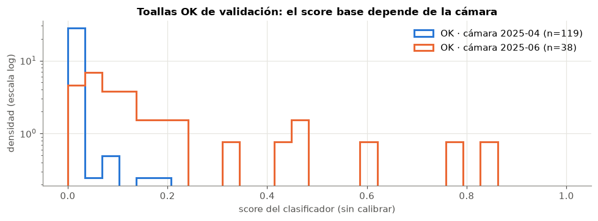

Figura 1. Score sin calibrar del clasificador en toallas OK de validación, por cámara. La de junio (producción) está desplazada hacia arriba.

## 4. Resultados

### 4.1 Por toalla (231 toallas de test, umbral fijado en validación)

| Método | AUC | Recall NO OK | Falsas alarmas OK | Recall · solo junio | F.A. · solo junio |
| --- | --- | --- | --- | --- | --- |
| Clasificador (seleccionado) | 0.936 | 91.9 % | 28.0 % | 90.0 % | 37.8 % |
| Ensamble OR (máx.) | 0.935 | 95.9 % | 31.8 % | 95.0 % | 43.2 % |
| YOLO11s | 0.815 | 91.9 % | 74.5 % | 97.5 % | 81.1 % |
| PatchCore | 0.756 | 97.3 % | 79.0 % | 97.5 % | 94.6 % |

Punto de operación `recall_98`. El recall en test queda por debajo del objetivo de validación porque solo hay ~40 toallas NO OK por cámara (cada una vale 2.5 puntos). La curva completa del clasificador en la cámara de producción es:

| Punto (objetivo en val) | Recall NO OK (junio, test) | Falsas alarmas OK | Precisión NO OK |
| --- | --- | --- | --- |
| `recall_90` | 82.5 % (33/40) | 8.1 % (3/37) | 91.7 % |
| `recall_95` | 87.5 % (35/40) | 16.2 % (6/37) | 85.4 % |
| `recall_98` (por defecto) | 90.0 % (36/40) | 37.8 % (14/37) | 72.0 % |

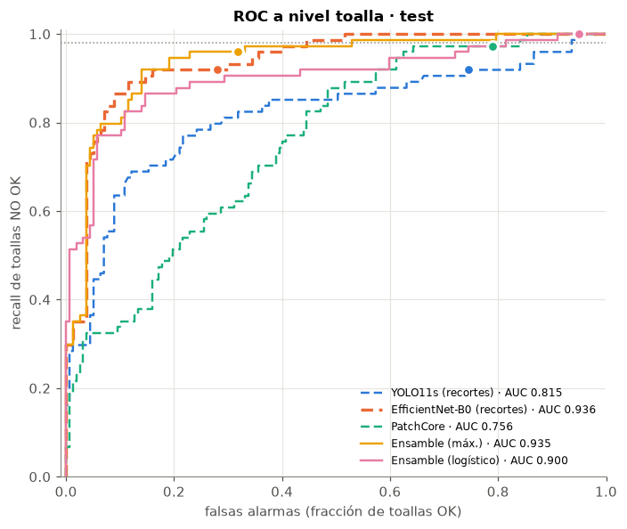

Figura 2. ROC por toalla en test. Los puntos marcan el umbral `recall_98` elegido en validación.

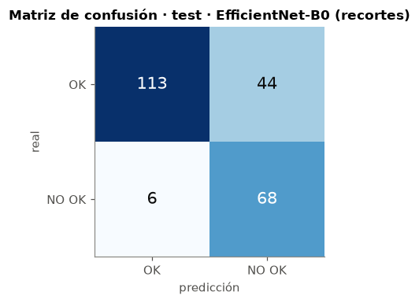

Figura 2b. Matriz de confusión en test (231 toallas, punto `recall_98`): 68 VP, 6 FN, 44 FP, 113 VN.

### 4.2 YOLO por recortes (validación)

mAP50 global de 0.473 (v1: 0.25, con otro set de validación y otras clases). La etiqueta de control alcanza mAP50 = 0.96, lo que valida la escala y el pipeline de datos. Los defectos pequeños quedan en ~0.25.

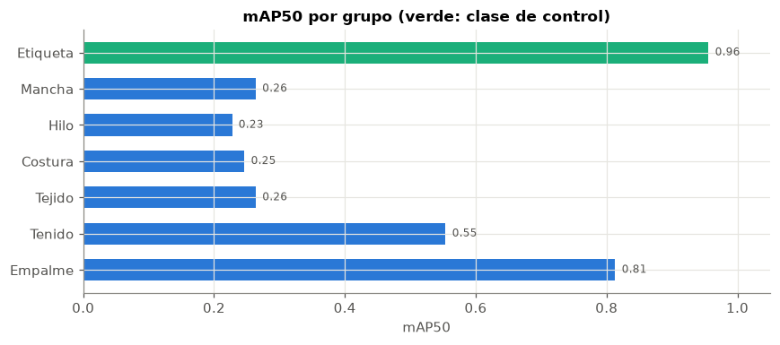

Figura 3. mAP50 por grupo (verde: clase de control).

### 4.3 ¿Qué se escapa?

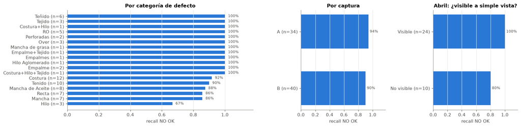

Figura 4. Recall en test por categoría original, por captura y por visibilidad (fuente A).

Las toallas NO OK de junio con score más bajo tienen **un único defecto pequeño**: manchas de ~40 px, costuras en esquinas (a veces junto a la etiqueta), hilos de ~15 px y **franjas de teñido muy tenues** que atraviesan toda la toalla. Un recorte de 512 px no puede ver estas franjas como anomalía, porque ocurren a baja frecuencia sobre la toalla completa.

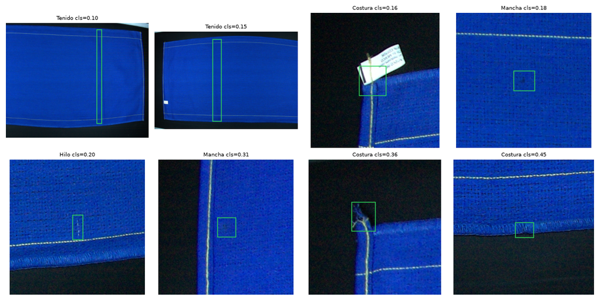

Figura 5. Las 8 toallas NO OK de junio (test) con menor score del clasificador (versión de un solo modelo). En verde, la caja anotada.

**Ojo con las "No visible".** El modelo marca el 80 % de las toallas "NG No visible" de abril (8 de 10). Puede ser que el defecto sí deje rastro en la foto, o que el modelo aproveche diferencias de la sesión de captura: las NO OK y las OK de abril se fotografiaron por separado. La evaluación definitiva tiene que hacerse con toallas de la línea, donde OK y NO OK comparten la misma sesión.

### 4.4 Experimentos de mejora (decididos solo en validación)

Cada variante se comparó en las 230 toallas de validación. La comparación usa el AUC por toalla con intervalo bootstrap del 95 %, el ΔAUC pareado contra el modelo base y las falsas alarmas al 95 % de recall. Regla: aceptar solo mejoras consistentes en la cámara de producción y en el total; ante empate, quedarse con lo más simple. El test se evaluó **una sola vez**, con la variante ya elegida.

| Variante | AUC val | AUC val · junio | Resultado |
| --- | --- | --- | --- |
| B0 base (v1 + negativos difíciles) | 0.904 | 0.942 | referencia |
| + TTA (volteos H/V) | 0.889 | 0.945 | sin mejora |
| Aumentación fuerte (brillo/contraste 0.35, saturación 0.25, tono ±0.02, desenfoque, ruido, recorte 85–100 %) | 0.854 | 0.942 | peor en abril (0.81) |
| Aumentación fuerte + copiar-pegar defectos de train (624 recortes) | 0.861 | 0.932 | peor |
| ConvNeXt-Tiny | 0.722 | 0.958 | inestable entre cámaras |
| B0 base + ConvNeXt-T (top2) | 0.915 | 0.958 | descartado: depende de un modelo frágil |
| B0 base + 2.º B0 (semilla 7), top2 | 0.914 | 0.949 | **elegido**; ΔAUC +0.009 [0.000, 0.021] |

La lista completa de experimentos, incluida la ronda 2 (ResNet50 y segmentador supervisado por cajas), está en el reporte de experimentos (documento 07).

## 5. Producto para producción

El servicio (`scripts/serve.py`, FastAPI + SQLite) corre en la PC de la línea con GPU NVIDIA:

1. La cámara guarda cada foto en una carpeta de entrada. El servicio la toma cuando el archivo ya terminó de escribirse.
2. Un único worker en la GPU ejecuta el clasificador (decisión) y YOLO (ubicación y tipo), en ~0.8 s por toalla.
3. La foto se archiva en `archivo/AAAA-MM-DD/{OK,NO_OK,errores}`. Se genera una vista previa con mapa de calor y cajas, y el resultado se registra en SQLite.
4. El **tablero en vivo** (Server-Sent Events) muestra:
   - KPIs del turno, la última toalla y la lista de inspecciones.
   - Toallas por hora y tipos de defecto.
   - Alertas: 5 NO OK seguidas, más de 50 % NO OK en las últimas 50, errores de lectura, línea sin actividad.
   - La **revisión del operador**: defecto real / falsa alarma, con atajos de teclado.
5. API REST: `/api/inspect` (subir una foto), `/api/summary`, `/api/inspections`, `/api/export.csv` para el reporte del turno, y `/api/health`.

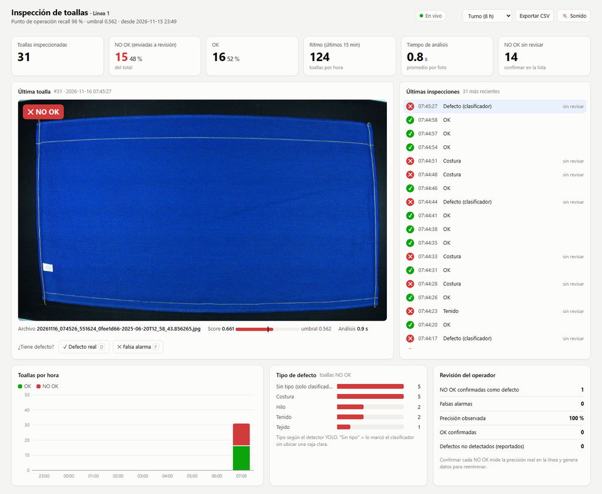

Figura 6. Tablero en vivo con 31 fotos de test de la cámara de junio enviadas por el simulador de línea (`scripts/simulate_line.py`).

```
python scripts/serve.py --inbox D:/camara/salida --archive D:/galia/archivo --line-name "Línea 1"
# pantalla de la línea: http://localhost:8000   (red interna: --host 0.0.0.0)
```

**La revisión del operador vale más que el tablero.** Cada NO OK confirmada o descartada es una etiqueta nueva tomada *en la cámara de producción*. Así se mide la precisión real y se construye el dataset del siguiente reentrenamiento, sin costo extra de anotación.

## 6. Propuesta de mejora

El objetivo de la siguiente versión, medido en la cámara de producción, es **recall ≥ 95 % con falsas alarmas ≤ 15 %**.

Fase 0 · Piloto en sombra · 2–4 semanas

- Instalar el servicio en la línea sin desviar toallas. El inspector humano sigue igual y además confirma las NO OK en el tablero.
- Cada turno, revisar una muestra de las OK (~5 %) para estimar los defectos que se escapan.
- Recalibrar con ≥ 200 fotos OK de producción y, si la prevalencia real lo justifica, mover el punto de operación.

Fase 1 · Datos y captura · 1–2 meses · mayor impacto esperado

- **Anotar ≥ 150 ejemplos** de cada tipo débil: manchas pequeñas, hilos, costura en esquinas y teñido tenue. Lo ideal es usar las NO OK confirmadas en el piloto.
- **Estandarizar la captura:** iluminación difusa cerrada, fondo uniforme, distancia y exposición fijas. Esto ataca de raíz el corrimiento entre cámaras.
- Considerar **luz rasante** o una segunda toma para defectos de relieve (hilos, tejido), y un recorte dedicado para esquinas y etiqueta.
- Definir un protocolo para "No visible": si el inspector no lo ve en la foto, no debe entrar al set de visión.

Fase 2 · Modelos · 2–4 meses

- Reentrenar el clasificador solo con la cámara de producción más las etiquetas del piloto. Probar recortes de 768 px y más miembros en la combinación (ConvNeXt-T y TTA ya se probaron sin ganancia estable, sección 4.4).
- **Detector de teñido a nivel toalla:** un modelo global de uniformidad de color (perfil de color por columna/fila sobre la máscara) para franjas largas y tenues.
- Segunda etapa para reducir falsas alarmas: un verificador sobre los 3 recortes más sospechosos, con más contexto y más resolución.
- PatchCore por modelo/color de toalla, entrenado con fotos OK de producción, como red de seguridad para defectos nuevos.
- Revisar el ensamble cuando haya ≥ 150 NO OK de producción en validación.

Fase 3 · Operación · continuo

- Reentrenamiento mensual con las revisiones del operador; versionado de modelos y umbrales.
- Monitoreo de deriva: score mediano de las OK por día, % NO OK y alerta de recalibración.
- Integración con el PLC para **desviar automáticamente** las NO OK, solo cuando la precisión observada lo justifique.
- Seguridad: el servicio no tiene autenticación y debe correr solo en la red interna. La contraseña de Label Studio que estuvo en el README debe rotarse.

## 7. Reproducibilidad

```
conda env create -f environment.yml && conda activate galia_v2
python scripts/04_build_dataset.py
python scripts/05_train_yolo_tiles.py --epochs 80
python scripts/06_train_tile_classifier.py --arch efficientnet_b0 --epochs 15
python scripts/06b_mine_hard_negatives.py --weights models/tile_cls_efficientnet_b0_v1.pt
python scripts/06_train_tile_classifier.py --init models/tile_cls_efficientnet_b0_v1.pt --epochs 6 --lr 1e-4 --hn-weight 3
python scripts/07_train_patchcore.py --max-tiles 1500 --coreset 0.01
python scripts/08_evaluate.py
```

El análisis completo con visualizaciones está en los notebooks 05–09. Las métricas detalladas están en `reports/metrics.md` y `reports/metrics.json`.